# Risk Factor Analysis

## Outcome Variable

**Outcome Variable:** ever_stunted

## Predictor Variables

**Intervention Variable:** nchldlt5

**Adjustment Set:**

- arm
- W_mage
- meducyrs
- feducyrs
- hhwealth_quart
- hfoodsec
- W_mhtcm
- W_mwtkg
- W_mbmi
- W_nrooms
- W_parity
- impfloor
- impsan
- safeh20
- delta_W_mage
- delta_meducyrs
- delta_feducyrs
- delta_hhwealth_quart
- delta_hfoodsec
- delta_W_mhtcm
- delta_W_mwtkg
- delta_W_mbmi
- delta_W_nrooms
- delta_W_parity
- delta_impfloor
- delta_impsan
- delta_safeh20

## Stratifying Variables

The analysis was stratified on these variable(s):

- agecat
- studyid
- country

## Data Summary

| agecat | studyid | country | nchldlt5 | ever_stunted | n_cell | n |
| --- | --- | --- | --- | --- | --- | --- |
| 0-24 months | ki1000108-IRC | INDIA | 1 | 0 | 35 | 410 |
| 0-24 months | ki1000108-IRC | INDIA | 1 | 1 | 54 | 410 |
| 0-24 months | ki1000108-IRC | INDIA | 2+ | 0 | 112 | 410 |
| 0-24 months | ki1000108-IRC | INDIA | 2+ | 1 | 209 | 410 |
| 0-24 months | ki1017093b-PROVIDE | BANGLADESH | 1 | 0 | 295 | 700 |
| 0-24 months | ki1017093b-PROVIDE | BANGLADESH | 1 | 1 | 217 | 700 |
| 0-24 months | ki1017093b-PROVIDE | BANGLADESH | 2+ | 0 | 100 | 700 |
| 0-24 months | ki1017093b-PROVIDE | BANGLADESH | 2+ | 1 | 88 | 700 |
| 0-24 months | ki1017093c-NIH-Crypto | BANGLADESH | 1 | 0 | 298 | 758 |
| 0-24 months | ki1017093c-NIH-Crypto | BANGLADESH | 1 | 1 | 243 | 758 |
| 0-24 months | ki1017093c-NIH-Crypto | BANGLADESH | 2+ | 0 | 98 | 758 |
| 0-24 months | ki1017093c-NIH-Crypto | BANGLADESH | 2+ | 1 | 119 | 758 |
| 0-24 months | ki1066203-TanzaniaChild2 | TANZANIA, UNITED REPUBLIC OF | 1 | 0 | 1077 | 2385 |
| 0-24 months | ki1066203-TanzaniaChild2 | TANZANIA, UNITED REPUBLIC OF | 1 | 1 | 560 | 2385 |
| 0-24 months | ki1066203-TanzaniaChild2 | TANZANIA, UNITED REPUBLIC OF | 2+ | 0 | 481 | 2385 |
| 0-24 months | ki1066203-TanzaniaChild2 | TANZANIA, UNITED REPUBLIC OF | 2+ | 1 | 267 | 2385 |
| 0-24 months | ki1112895-iLiNS-Zinc | BURKINA FASO | 1 | 0 | 711 | 3188 |
| 0-24 months | ki1112895-iLiNS-Zinc | BURKINA FASO | 1 | 1 | 362 | 3188 |
| 0-24 months | ki1112895-iLiNS-Zinc | BURKINA FASO | 2+ | 0 | 1339 | 3188 |
| 0-24 months | ki1112895-iLiNS-Zinc | BURKINA FASO | 2+ | 1 | 776 | 3188 |
| 0-24 months | ki1148112-LCNI-5 | MALAWI | 1 | 0 | 145 | 812 |
| 0-24 months | ki1148112-LCNI-5 | MALAWI | 1 | 1 | 246 | 812 |
| 0-24 months | ki1148112-LCNI-5 | MALAWI | 2+ | 0 | 150 | 812 |
| 0-24 months | ki1148112-LCNI-5 | MALAWI | 2+ | 1 | 271 | 812 |
| 0-24 months | kiGH5241-JiVitA-3 | BANGLADESH | 1 | 0 | 8536 | 27200 |
| 0-24 months | kiGH5241-JiVitA-3 | BANGLADESH | 1 | 1 | 8874 | 27200 |
| 0-24 months | kiGH5241-JiVitA-3 | BANGLADESH | 2+ | 0 | 5189 | 27200 |
| 0-24 months | kiGH5241-JiVitA-3 | BANGLADESH | 2+ | 1 | 4601 | 27200 |
| 0-6 months | ki1000108-IRC | INDIA | 1 | 0 | 49 | 410 |
| 0-6 months | ki1000108-IRC | INDIA | 1 | 1 | 40 | 410 |
| 0-6 months | ki1000108-IRC | INDIA | 2+ | 0 | 187 | 410 |
| 0-6 months | ki1000108-IRC | INDIA | 2+ | 1 | 134 | 410 |
| 0-6 months | ki1017093b-PROVIDE | BANGLADESH | 1 | 0 | 383 | 700 |
| 0-6 months | ki1017093b-PROVIDE | BANGLADESH | 1 | 1 | 129 | 700 |
| 0-6 months | ki1017093b-PROVIDE | BANGLADESH | 2+ | 0 | 149 | 700 |
| 0-6 months | ki1017093b-PROVIDE | BANGLADESH | 2+ | 1 | 39 | 700 |
| 0-6 months | ki1017093c-NIH-Crypto | BANGLADESH | 1 | 0 | 386 | 758 |
| 0-6 months | ki1017093c-NIH-Crypto | BANGLADESH | 1 | 1 | 155 | 758 |
| 0-6 months | ki1017093c-NIH-Crypto | BANGLADESH | 2+ | 0 | 143 | 758 |
| 0-6 months | ki1017093c-NIH-Crypto | BANGLADESH | 2+ | 1 | 74 | 758 |
| 0-6 months | ki1066203-TanzaniaChild2 | TANZANIA, UNITED REPUBLIC OF | 1 | 0 | 1311 | 2385 |
| 0-6 months | ki1066203-TanzaniaChild2 | TANZANIA, UNITED REPUBLIC OF | 1 | 1 | 326 | 2385 |
| 0-6 months | ki1066203-TanzaniaChild2 | TANZANIA, UNITED REPUBLIC OF | 2+ | 0 | 609 | 2385 |
| 0-6 months | ki1066203-TanzaniaChild2 | TANZANIA, UNITED REPUBLIC OF | 2+ | 1 | 139 | 2385 |
| 0-6 months | ki1148112-LCNI-5 | MALAWI | 1 | 0 | 81 | 267 |
| 0-6 months | ki1148112-LCNI-5 | MALAWI | 1 | 1 | 41 | 267 |
| 0-6 months | ki1148112-LCNI-5 | MALAWI | 2+ | 0 | 91 | 267 |
| 0-6 months | ki1148112-LCNI-5 | MALAWI | 2+ | 1 | 54 | 267 |
| 0-6 months | kiGH5241-JiVitA-3 | BANGLADESH | 1 | 0 | 9780 | 27134 |
| 0-6 months | kiGH5241-JiVitA-3 | BANGLADESH | 1 | 1 | 7579 | 27134 |
| 0-6 months | kiGH5241-JiVitA-3 | BANGLADESH | 2+ | 0 | 6146 | 27134 |
| 0-6 months | kiGH5241-JiVitA-3 | BANGLADESH | 2+ | 1 | 3629 | 27134 |
| 6-24 months | ki1000108-IRC | INDIA | 1 | 0 | 35 | 236 |
| 6-24 months | ki1000108-IRC | INDIA | 1 | 1 | 14 | 236 |
| 6-24 months | ki1000108-IRC | INDIA | 2+ | 0 | 112 | 236 |
| 6-24 months | ki1000108-IRC | INDIA | 2+ | 1 | 75 | 236 |
| 6-24 months | ki1017093b-PROVIDE | BANGLADESH | 1 | 0 | 238 | 456 |
| 6-24 months | ki1017093b-PROVIDE | BANGLADESH | 1 | 1 | 88 | 456 |
| 6-24 months | ki1017093b-PROVIDE | BANGLADESH | 2+ | 0 | 81 | 456 |
| 6-24 months | ki1017093b-PROVIDE | BANGLADESH | 2+ | 1 | 49 | 456 |
| 6-24 months | ki1017093c-NIH-Crypto | BANGLADESH | 1 | 0 | 280 | 506 |
| 6-24 months | ki1017093c-NIH-Crypto | BANGLADESH | 1 | 1 | 88 | 506 |
| 6-24 months | ki1017093c-NIH-Crypto | BANGLADESH | 2+ | 0 | 93 | 506 |
| 6-24 months | ki1017093c-NIH-Crypto | BANGLADESH | 2+ | 1 | 45 | 506 |
| 6-24 months | ki1066203-TanzaniaChild2 | TANZANIA, UNITED REPUBLIC OF | 1 | 0 | 858 | 1596 |
| 6-24 months | ki1066203-TanzaniaChild2 | TANZANIA, UNITED REPUBLIC OF | 1 | 1 | 234 | 1596 |
| 6-24 months | ki1066203-TanzaniaChild2 | TANZANIA, UNITED REPUBLIC OF | 2+ | 0 | 376 | 1596 |
| 6-24 months | ki1066203-TanzaniaChild2 | TANZANIA, UNITED REPUBLIC OF | 2+ | 1 | 128 | 1596 |
| 6-24 months | ki1112895-iLiNS-Zinc | BURKINA FASO | 1 | 0 | 711 | 3188 |
| 6-24 months | ki1112895-iLiNS-Zinc | BURKINA FASO | 1 | 1 | 362 | 3188 |
| 6-24 months | ki1112895-iLiNS-Zinc | BURKINA FASO | 2+ | 0 | 1339 | 3188 |
| 6-24 months | ki1112895-iLiNS-Zinc | BURKINA FASO | 2+ | 1 | 776 | 3188 |
| 6-24 months | ki1148112-LCNI-5 | MALAWI | 1 | 0 | 138 | 705 |
| 6-24 months | ki1148112-LCNI-5 | MALAWI | 1 | 1 | 205 | 705 |
| 6-24 months | ki1148112-LCNI-5 | MALAWI | 2+ | 0 | 145 | 705 |
| 6-24 months | ki1148112-LCNI-5 | MALAWI | 2+ | 1 | 217 | 705 |
| 6-24 months | kiGH5241-JiVitA-3 | BANGLADESH | 1 | 0 | 5238 | 10487 |
| 6-24 months | kiGH5241-JiVitA-3 | BANGLADESH | 1 | 1 | 1295 | 10487 |
| 6-24 months | kiGH5241-JiVitA-3 | BANGLADESH | 2+ | 0 | 2982 | 10487 |
| 6-24 months | kiGH5241-JiVitA-3 | BANGLADESH | 2+ | 1 | 972 | 10487 |

The following strata were considered:

- agecat: 0-24 months, studyid: ki1000108-IRC, country: INDIA
- agecat: 0-24 months, studyid: ki1017093b-PROVIDE, country: BANGLADESH
- agecat: 0-24 months, studyid: ki1017093c-NIH-Crypto, country: BANGLADESH
- agecat: 0-24 months, studyid: ki1066203-TanzaniaChild2, country: TANZANIA, UNITED REPUBLIC OF
- agecat: 0-24 months, studyid: ki1112895-iLiNS-Zinc, country: BURKINA FASO
- agecat: 0-24 months, studyid: ki1148112-LCNI-5, country: MALAWI
- agecat: 0-24 months, studyid: kiGH5241-JiVitA-3, country: BANGLADESH
- agecat: 0-6 months, studyid: ki1000108-IRC, country: INDIA
- agecat: 0-6 months, studyid: ki1017093b-PROVIDE, country: BANGLADESH
- agecat: 0-6 months, studyid: ki1017093c-NIH-Crypto, country: BANGLADESH
- agecat: 0-6 months, studyid: ki1066203-TanzaniaChild2, country: TANZANIA, UNITED REPUBLIC OF
- agecat: 0-6 months, studyid: ki1148112-LCNI-5, country: MALAWI
- agecat: 0-6 months, studyid: kiGH5241-JiVitA-3, country: BANGLADESH
- agecat: 6-24 months, studyid: ki1000108-IRC, country: INDIA
- agecat: 6-24 months, studyid: ki1017093b-PROVIDE, country: BANGLADESH
- agecat: 6-24 months, studyid: ki1017093c-NIH-Crypto, country: BANGLADESH
- agecat: 6-24 months, studyid: ki1066203-TanzaniaChild2, country: TANZANIA, UNITED REPUBLIC OF
- agecat: 6-24 months, studyid: ki1112895-iLiNS-Zinc, country: BURKINA FASO
- agecat: 6-24 months, studyid: ki1148112-LCNI-5, country: MALAWI
- agecat: 6-24 months, studyid: kiGH5241-JiVitA-3, country: BANGLADESH

## Methods Detail

We’re interested in the causal parameters $E[Y_a]$ for all values of $a \in \mathcal{A}$. These parameters represent the mean outcome if, possibly contrary to fact, we intervened to set all units to have $A=a$. Under the randomization and positivity assumptions, these are identified by the statistical parameters $\psi_a=E_W[E_{Y|A,W}(Y|A=a,W)]$. In addition, we’re interested in the mean of $Y$, $E[Y]$ under no intervention (the observed mean). We will estimate these parameters by using SuperLearner to fit the relevant likelihood factors – $E_{Y|A,W}(Y|A=a,W)$ and $p(A=a|W)$, and then updating our likelihood fit using a joint TMLE.

For unadjusted analyses ($W=\{\}$), initial likelihoods were estimated using Lrnr_glm to estimate the simple $E(Y|A)$ and Lrnr_mean to estimate $p(A)$. For adjusted analyses, a small library containing Lrnr_glmnet, Lrnr_xgboost, and Lrnr_mean was used.

Having estimated these parameters, we will then use the delta method to estimate relative risks and attributable risks relative to a prespecified baseline level of $A$.

# Results Detail

## Results Plots

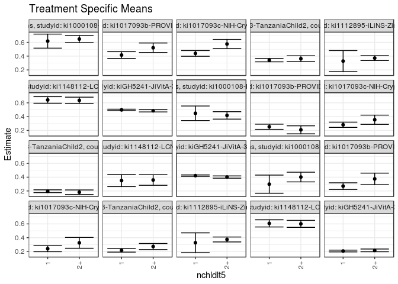

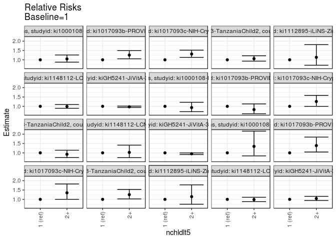

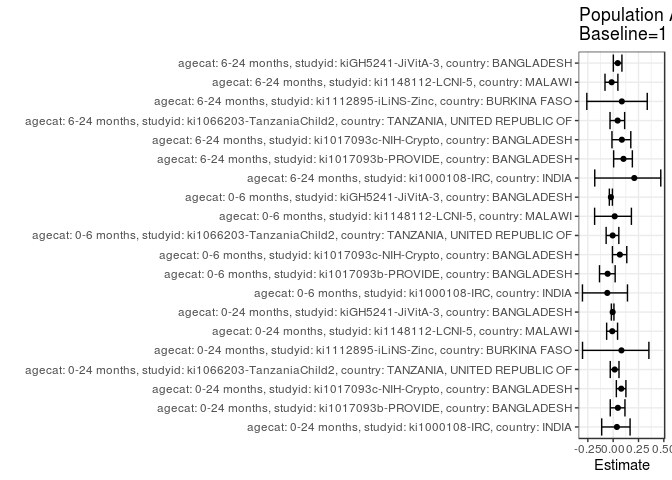

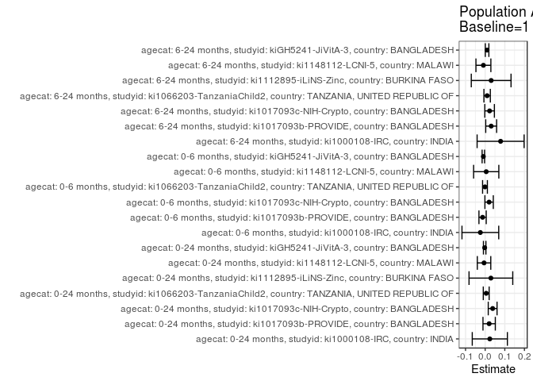

## Results Table

### Parameter: TSM

| agecat | studyid | country | intervention_level | baseline_level | estimate | ci_lower | ci_upper |
| --- | --- | --- | --- | --- | --- | --- | --- |
| 0-24 months | ki1000108-IRC | INDIA | 1 | NA | 0.6177500 | 0.5159452 | 0.7195547 |
| 0-24 months | ki1000108-IRC | INDIA | 2+ | NA | 0.6476968 | 0.5954656 | 0.6999281 |
| 0-24 months | ki1017093b-PROVIDE | BANGLADESH | 1 | NA | 0.4154123 | 0.3661858 | 0.4646389 |
| 0-24 months | ki1017093b-PROVIDE | BANGLADESH | 2+ | NA | 0.5213233 | 0.4521268 | 0.5905199 |
| 0-24 months | ki1017093c-NIH-Crypto | BANGLADESH | 1 | NA | 0.4394668 | 0.3978077 | 0.4811260 |
| 0-24 months | ki1017093c-NIH-Crypto | BANGLADESH | 2+ | NA | 0.5756565 | 0.5092281 | 0.6420850 |
| 0-24 months | ki1066203-TanzaniaChild2 | TANZANIA, UNITED REPUBLIC OF | 1 | NA | 0.3414159 | 0.3171406 | 0.3656911 |
| 0-24 months | ki1066203-TanzaniaChild2 | TANZANIA, UNITED REPUBLIC OF | 2+ | NA | 0.3626982 | 0.3207059 | 0.4046906 |
| 0-24 months | ki1112895-iLiNS-Zinc | BURKINA FASO | 1 | NA | 0.3277740 | 0.1744898 | 0.4810582 |
| 0-24 months | ki1112895-iLiNS-Zinc | BURKINA FASO | 2+ | NA | 0.3714168 | 0.3364487 | 0.4063849 |
| 0-24 months | ki1148112-LCNI-5 | MALAWI | 1 | NA | 0.6424178 | 0.5945862 | 0.6902493 |
| 0-24 months | ki1148112-LCNI-5 | MALAWI | 2+ | NA | 0.6366775 | 0.5909218 | 0.6824332 |
| 0-24 months | kiGH5241-JiVitA-3 | BANGLADESH | 1 | NA | 0.4978945 | 0.4875336 | 0.5082555 |
| 0-24 months | kiGH5241-JiVitA-3 | BANGLADESH | 2+ | NA | 0.4848776 | 0.4686002 | 0.5011549 |
| 0-6 months | ki1000108-IRC | INDIA | 1 | NA | 0.4489118 | 0.3433934 | 0.5544302 |
| 0-6 months | ki1000108-IRC | INDIA | 2+ | NA | 0.4180100 | 0.3640291 | 0.4719909 |
| 0-6 months | ki1017093b-PROVIDE | BANGLADESH | 1 | NA | 0.2531423 | 0.2156976 | 0.2905870 |
| 0-6 months | ki1017093b-PROVIDE | BANGLADESH | 2+ | NA | 0.2088961 | 0.1507486 | 0.2670437 |
| 0-6 months | ki1017093c-NIH-Crypto | BANGLADESH | 1 | NA | 0.2820824 | 0.2440107 | 0.3201541 |
| 0-6 months | ki1017093c-NIH-Crypto | BANGLADESH | 2+ | NA | 0.3549963 | 0.2879686 | 0.4220239 |
| 0-6 months | ki1066203-TanzaniaChild2 | TANZANIA, UNITED REPUBLIC OF | 1 | NA | 0.1959025 | 0.1756674 | 0.2161377 |
| 0-6 months | ki1066203-TanzaniaChild2 | TANZANIA, UNITED REPUBLIC OF | 2+ | NA | 0.1810260 | 0.1475297 | 0.2145222 |
| 0-6 months | ki1148112-LCNI-5 | MALAWI | 1 | NA | 0.3504428 | 0.2633199 | 0.4375656 |
| 0-6 months | ki1148112-LCNI-5 | MALAWI | 2+ | NA | 0.3587704 | 0.2819427 | 0.4355981 |
| 0-6 months | kiGH5241-JiVitA-3 | BANGLADESH | 1 | NA | 0.4223283 | 0.4122848 | 0.4323717 |
| 0-6 months | kiGH5241-JiVitA-3 | BANGLADESH | 2+ | NA | 0.4017057 | 0.3853226 | 0.4180889 |
| 6-24 months | ki1000108-IRC | INDIA | 1 | NA | 0.2984705 | 0.1668461 | 0.4300948 |
| 6-24 months | ki1000108-IRC | INDIA | 2+ | NA | 0.4016299 | 0.3311732 | 0.4720866 |
| 6-24 months | ki1017093b-PROVIDE | BANGLADESH | 1 | NA | 0.2698314 | 0.2216175 | 0.3180454 |
| 6-24 months | ki1017093b-PROVIDE | BANGLADESH | 2+ | NA | 0.3747064 | 0.2907222 | 0.4586906 |
| 6-24 months | ki1017093c-NIH-Crypto | BANGLADESH | 1 | NA | 0.2402967 | 0.1966228 | 0.2839706 |
| 6-24 months | ki1017093c-NIH-Crypto | BANGLADESH | 2+ | NA | 0.3250334 | 0.2464641 | 0.4036028 |
| 6-24 months | ki1066203-TanzaniaChild2 | TANZANIA, UNITED REPUBLIC OF | 1 | NA | 0.2168523 | 0.1908199 | 0.2428847 |
| 6-24 months | ki1066203-TanzaniaChild2 | TANZANIA, UNITED REPUBLIC OF | 2+ | NA | 0.2715918 | 0.2274788 | 0.3157049 |
| 6-24 months | ki1112895-iLiNS-Zinc | BURKINA FASO | 1 | NA | 0.3264073 | 0.1825481 | 0.4702665 |
| 6-24 months | ki1112895-iLiNS-Zinc | BURKINA FASO | 2+ | NA | 0.3741337 | 0.3384670 | 0.4098003 |
| 6-24 months | ki1148112-LCNI-5 | MALAWI | 1 | NA | 0.6075674 | 0.5553540 | 0.6597808 |
| 6-24 months | ki1148112-LCNI-5 | MALAWI | 2+ | NA | 0.6005504 | 0.5499743 | 0.6511266 |
| 6-24 months | kiGH5241-JiVitA-3 | BANGLADESH | 1 | NA | 0.2064263 | 0.1935921 | 0.2192605 |
| 6-24 months | kiGH5241-JiVitA-3 | BANGLADESH | 2+ | NA | 0.2158704 | 0.1960443 | 0.2356964 |

### Parameter: E(Y)

| agecat | studyid | country | intervention_level | baseline_level | estimate | ci_lower | ci_upper |
| --- | --- | --- | --- | --- | --- | --- | --- |
| 0-24 months | ki1000108-IRC | INDIA | NA | NA | 0.6414634 | 0.5949863 | 0.6879405 |
| 0-24 months | ki1017093b-PROVIDE | BANGLADESH | NA | NA | 0.4357143 | 0.3989556 | 0.4724730 |
| 0-24 months | ki1017093c-NIH-Crypto | BANGLADESH | NA | NA | 0.4775726 | 0.4419904 | 0.5131548 |
| 0-24 months | ki1066203-TanzaniaChild2 | TANZANIA, UNITED REPUBLIC OF | NA | NA | 0.3467505 | 0.3276457 | 0.3658553 |
| 0-24 months | ki1112895-iLiNS-Zinc | BURKINA FASO | NA | NA | 0.3569636 | 0.3068991 | 0.4070281 |
| 0-24 months | ki1148112-LCNI-5 | MALAWI | NA | NA | 0.6366995 | 0.6035988 | 0.6698003 |
| 0-24 months | kiGH5241-JiVitA-3 | BANGLADESH | NA | NA | 0.4954044 | 0.4875673 | 0.5032416 |
| 0-6 months | ki1000108-IRC | INDIA | NA | NA | 0.4243902 | 0.3764905 | 0.4722900 |
| 0-6 months | ki1017093b-PROVIDE | BANGLADESH | NA | NA | 0.2400000 | 0.2083392 | 0.2716608 |
| 0-6 months | ki1017093c-NIH-Crypto | BANGLADESH | NA | NA | 0.3021108 | 0.2694011 | 0.3348205 |
| 0-6 months | ki1066203-TanzaniaChild2 | TANZANIA, UNITED REPUBLIC OF | NA | NA | 0.1949686 | 0.1790654 | 0.2108717 |
| 0-6 months | ki1148112-LCNI-5 | MALAWI | NA | NA | 0.3558052 | 0.2982716 | 0.4133389 |
| 0-6 months | kiGH5241-JiVitA-3 | BANGLADESH | NA | NA | 0.4130611 | 0.4056124 | 0.4205098 |
| 6-24 months | ki1000108-IRC | INDIA | NA | NA | 0.3771186 | 0.3151523 | 0.4390850 |
| 6-24 months | ki1017093b-PROVIDE | BANGLADESH | NA | NA | 0.3004386 | 0.2583143 | 0.3425629 |
| 6-24 months | ki1017093c-NIH-Crypto | BANGLADESH | NA | NA | 0.2628458 | 0.2244546 | 0.3012371 |
| 6-24 months | ki1066203-TanzaniaChild2 | TANZANIA, UNITED REPUBLIC OF | NA | NA | 0.2268170 | 0.2062654 | 0.2473687 |
| 6-24 months | ki1112895-iLiNS-Zinc | BURKINA FASO | NA | NA | 0.3569636 | 0.3068991 | 0.4070281 |
| 6-24 months | ki1148112-LCNI-5 | MALAWI | NA | NA | 0.5985816 | 0.5623721 | 0.6347910 |
| 6-24 months | kiGH5241-JiVitA-3 | BANGLADESH | NA | NA | 0.2161724 | 0.2067972 | 0.2255476 |

### Parameter: RR

| agecat | studyid | country | intervention_level | baseline_level | estimate | ci_lower | ci_upper |
| --- | --- | --- | --- | --- | --- | --- | --- |
| 0-24 months | ki1000108-IRC | INDIA | 1 | 1 | 1.0000000 | 1.0000000 | 1.0000000 |
| 0-24 months | ki1000108-IRC | INDIA | 2+ | 1 | 1.0484773 | 0.8735567 | 1.2584240 |
| 0-24 months | ki1017093b-PROVIDE | BANGLADESH | 1 | 1 | 1.0000000 | 1.0000000 | 1.0000000 |
| 0-24 months | ki1017093b-PROVIDE | BANGLADESH | 2+ | 1 | 1.2549539 | 1.0552309 | 1.4924783 |
| 0-24 months | ki1017093c-NIH-Crypto | BANGLADESH | 1 | 1 | 1.0000000 | 1.0000000 | 1.0000000 |
| 0-24 months | ki1017093c-NIH-Crypto | BANGLADESH | 2+ | 1 | 1.3098976 | 1.1311972 | 1.5168281 |
| 0-24 months | ki1066203-TanzaniaChild2 | TANZANIA, UNITED REPUBLIC OF | 1 | 1 | 1.0000000 | 1.0000000 | 1.0000000 |
| 0-24 months | ki1066203-TanzaniaChild2 | TANZANIA, UNITED REPUBLIC OF | 2+ | 1 | 1.0623356 | 0.9278937 | 1.2162567 |
| 0-24 months | ki1112895-iLiNS-Zinc | BURKINA FASO | 1 | 1 | 1.0000000 | 1.0000000 | 1.0000000 |
| 0-24 months | ki1112895-iLiNS-Zinc | BURKINA FASO | 2+ | 1 | 1.1331489 | 0.7078983 | 1.8138572 |
| 0-24 months | ki1148112-LCNI-5 | MALAWI | 1 | 1 | 1.0000000 | 1.0000000 | 1.0000000 |
| 0-24 months | ki1148112-LCNI-5 | MALAWI | 2+ | 1 | 0.9910646 | 0.8949743 | 1.0974719 |
| 0-24 months | kiGH5241-JiVitA-3 | BANGLADESH | 1 | 1 | 1.0000000 | 1.0000000 | 1.0000000 |
| 0-24 months | kiGH5241-JiVitA-3 | BANGLADESH | 2+ | 1 | 0.9738560 | 0.9384435 | 1.0106048 |
| 0-6 months | ki1000108-IRC | INDIA | 1 | 1 | 1.0000000 | 1.0000000 | 1.0000000 |
| 0-6 months | ki1000108-IRC | INDIA | 2+ | 1 | 0.9311628 | 0.7123917 | 1.2171172 |
| 0-6 months | ki1017093b-PROVIDE | BANGLADESH | 1 | 1 | 1.0000000 | 1.0000000 | 1.0000000 |
| 0-6 months | ki1017093b-PROVIDE | BANGLADESH | 2+ | 1 | 0.8252123 | 0.6027434 | 1.1297930 |
| 0-6 months | ki1017093c-NIH-Crypto | BANGLADESH | 1 | 1 | 1.0000000 | 1.0000000 | 1.0000000 |
| 0-6 months | ki1017093c-NIH-Crypto | BANGLADESH | 2+ | 1 | 1.2584841 | 0.9989885 | 1.5853858 |
| 0-6 months | ki1066203-TanzaniaChild2 | TANZANIA, UNITED REPUBLIC OF | 1 | 1 | 1.0000000 | 1.0000000 | 1.0000000 |
| 0-6 months | ki1066203-TanzaniaChild2 | TANZANIA, UNITED REPUBLIC OF | 2+ | 1 | 0.9240613 | 0.7481920 | 1.1412703 |
| 0-6 months | ki1148112-LCNI-5 | MALAWI | 1 | 1 | 1.0000000 | 1.0000000 | 1.0000000 |
| 0-6 months | ki1148112-LCNI-5 | MALAWI | 2+ | 1 | 1.0237631 | 0.7422691 | 1.4120094 |
| 0-6 months | kiGH5241-JiVitA-3 | BANGLADESH | 1 | 1 | 1.0000000 | 1.0000000 | 1.0000000 |
| 0-6 months | kiGH5241-JiVitA-3 | BANGLADESH | 2+ | 1 | 0.9511694 | 0.9086998 | 0.9956239 |
| 6-24 months | ki1000108-IRC | INDIA | 1 | 1 | 1.0000000 | 1.0000000 | 1.0000000 |
| 6-24 months | ki1000108-IRC | INDIA | 2+ | 1 | 1.3456269 | 0.8372274 | 2.1627479 |
| 6-24 months | ki1017093b-PROVIDE | BANGLADESH | 1 | 1 | 1.0000000 | 1.0000000 | 1.0000000 |
| 6-24 months | ki1017093b-PROVIDE | BANGLADESH | 2+ | 1 | 1.3886686 | 1.0450480 | 1.8452746 |
| 6-24 months | ki1017093c-NIH-Crypto | BANGLADESH | 1 | 1 | 1.0000000 | 1.0000000 | 1.0000000 |
| 6-24 months | ki1017093c-NIH-Crypto | BANGLADESH | 2+ | 1 | 1.3526336 | 1.0023314 | 1.8253622 |
| 6-24 months | ki1066203-TanzaniaChild2 | TANZANIA, UNITED REPUBLIC OF | 1 | 1 | 1.0000000 | 1.0000000 | 1.0000000 |
| 6-24 months | ki1066203-TanzaniaChild2 | TANZANIA, UNITED REPUBLIC OF | 2+ | 1 | 1.2524277 | 1.0236470 | 1.5323399 |
| 6-24 months | ki1112895-iLiNS-Zinc | BURKINA FASO | 1 | 1 | 1.0000000 | 1.0000000 | 1.0000000 |
| 6-24 months | ki1112895-iLiNS-Zinc | BURKINA FASO | 2+ | 1 | 1.1462172 | 0.7391580 | 1.7774465 |
| 6-24 months | ki1148112-LCNI-5 | MALAWI | 1 | 1 | 1.0000000 | 1.0000000 | 1.0000000 |
| 6-24 months | ki1148112-LCNI-5 | MALAWI | 2+ | 1 | 0.9884507 | 0.8780459 | 1.1127378 |
| 6-24 months | kiGH5241-JiVitA-3 | BANGLADESH | 1 | 1 | 1.0000000 | 1.0000000 | 1.0000000 |
| 6-24 months | kiGH5241-JiVitA-3 | BANGLADESH | 2+ | 1 | 1.0457500 | 0.9403157 | 1.1630063 |

### Parameter: PAR

| agecat | studyid | country | intervention_level | baseline_level | estimate | ci_lower | ci_upper |
| --- | --- | --- | --- | --- | --- | --- | --- |
| 0-24 months | ki1000108-IRC | INDIA | 1 | NA | 0.0237135 | -0.0657287 | 0.1131556 |
| 0-24 months | ki1017093b-PROVIDE | BANGLADESH | 1 | NA | 0.0203020 | -0.0111429 | 0.0517468 |
| 0-24 months | ki1017093c-NIH-Crypto | BANGLADESH | 1 | NA | 0.0381057 | 0.0157304 | 0.0604811 |
| 0-24 months | ki1066203-TanzaniaChild2 | TANZANIA, UNITED REPUBLIC OF | 1 | NA | 0.0053347 | -0.0095916 | 0.0202609 |
| 0-24 months | ki1112895-iLiNS-Zinc | BURKINA FASO | 1 | NA | 0.0291896 | -0.0821788 | 0.1405580 |
| 0-24 months | ki1148112-LCNI-5 | MALAWI | 1 | NA | -0.0057182 | -0.0400020 | 0.0285655 |
| 0-24 months | kiGH5241-JiVitA-3 | BANGLADESH | 1 | NA | -0.0024901 | -0.0088393 | 0.0038590 |
| 0-6 months | ki1000108-IRC | INDIA | 1 | NA | -0.0245216 | -0.1181280 | 0.0690849 |
| 0-6 months | ki1017093b-PROVIDE | BANGLADESH | 1 | NA | -0.0131423 | -0.0316686 | 0.0053840 |
| 0-6 months | ki1017093c-NIH-Crypto | BANGLADESH | 1 | NA | 0.0200284 | -0.0013287 | 0.0413855 |
| 0-6 months | ki1066203-TanzaniaChild2 | TANZANIA, UNITED REPUBLIC OF | 1 | NA | -0.0009340 | -0.0131299 | 0.0112619 |
| 0-6 months | ki1148112-LCNI-5 | MALAWI | 1 | NA | 0.0053625 | -0.0588534 | 0.0695783 |
| 0-6 months | kiGH5241-JiVitA-3 | BANGLADESH | 1 | NA | -0.0092672 | -0.0155400 | -0.0029943 |
| 6-24 months | ki1000108-IRC | INDIA | 1 | NA | 0.0786482 | -0.0410204 | 0.1983168 |
| 6-24 months | ki1017093b-PROVIDE | BANGLADESH | 1 | NA | 0.0306072 | 0.0028585 | 0.0583559 |
| 6-24 months | ki1017093c-NIH-Crypto | BANGLADESH | 1 | NA | 0.0225491 | -0.0019064 | 0.0470046 |
| 6-24 months | ki1066203-TanzaniaChild2 | TANZANIA, UNITED REPUBLIC OF | 1 | NA | 0.0099647 | -0.0063783 | 0.0263077 |
| 6-24 months | ki1112895-iLiNS-Zinc | BURKINA FASO | 1 | NA | 0.0305563 | -0.0706841 | 0.1317967 |
| 6-24 months | ki1148112-LCNI-5 | MALAWI | 1 | NA | -0.0089859 | -0.0470099 | 0.0290382 |
| 6-24 months | kiGH5241-JiVitA-3 | BANGLADESH | 1 | NA | 0.0097461 | 0.0005960 | 0.0188961 |

### Parameter: PAF

| agecat | studyid | country | intervention_level | baseline_level | estimate | ci_lower | ci_upper |
| --- | --- | --- | --- | --- | --- | --- | --- |
| 0-24 months | ki1000108-IRC | INDIA | 1 | NA | 0.0369677 | -0.1131720 | 0.1668573 |
| 0-24 months | ki1017093b-PROVIDE | BANGLADESH | 1 | NA | 0.0465947 | -0.0286432 | 0.1163294 |
| 0-24 months | ki1017093c-NIH-Crypto | BANGLADESH | 1 | NA | 0.0797904 | 0.0314516 | 0.1257167 |
| 0-24 months | ki1066203-TanzaniaChild2 | TANZANIA, UNITED REPUBLIC OF | 1 | NA | 0.0153847 | -0.0286273 | 0.0575136 |
| 0-24 months | ki1112895-iLiNS-Zinc | BURKINA FASO | 1 | NA | 0.0817719 | -0.3023508 | 0.3525993 |
| 0-24 months | ki1148112-LCNI-5 | MALAWI | 1 | NA | -0.0089811 | -0.0642882 | 0.0434520 |
| 0-24 months | kiGH5241-JiVitA-3 | BANGLADESH | 1 | NA | -0.0050264 | -0.0179203 | 0.0077041 |
| 0-6 months | ki1000108-IRC | INDIA | 1 | NA | -0.0577807 | -0.3030784 | 0.1413409 |
| 0-6 months | ki1017093b-PROVIDE | BANGLADESH | 1 | NA | -0.0547597 | -0.1348370 | 0.0196671 |
| 0-6 months | ki1017093c-NIH-Crypto | BANGLADESH | 1 | NA | 0.0662948 | -0.0071116 | 0.1343508 |
| 0-6 months | ki1066203-TanzaniaChild2 | TANZANIA, UNITED REPUBLIC OF | 1 | NA | -0.0047904 | -0.0693246 | 0.0558491 |
| 0-6 months | ki1148112-LCNI-5 | MALAWI | 1 | NA | 0.0150714 | -0.1830846 | 0.1800380 |
| 0-6 months | kiGH5241-JiVitA-3 | BANGLADESH | 1 | NA | -0.0224354 | -0.0377139 | -0.0073818 |
| 6-24 months | ki1000108-IRC | INDIA | 1 | NA | 0.2085502 | -0.1816947 | 0.4699199 |
| 6-24 months | ki1017093b-PROVIDE | BANGLADESH | 1 | NA | 0.1018750 | 0.0048632 | 0.1894295 |
| 6-24 months | ki1017093c-NIH-Crypto | BANGLADESH | 1 | NA | 0.0857884 | -0.0118703 | 0.1740218 |
| 6-24 months | ki1066203-TanzaniaChild2 | TANZANIA, UNITED REPUBLIC OF | 1 | NA | 0.0439329 | -0.0309488 | 0.1133756 |
| 6-24 months | ki1112895-iLiNS-Zinc | BURKINA FASO | 1 | NA | 0.0856006 | -0.2599412 | 0.3363768 |
| 6-24 months | ki1148112-LCNI-5 | MALAWI | 1 | NA | -0.0150119 | -0.0805831 | 0.0465803 |
| 6-24 months | kiGH5241-JiVitA-3 | BANGLADESH | 1 | NA | 0.0450847 | 0.0018400 | 0.0864558 |